# Mosquito Metagenomics

Cole Baril

2023-05-07

# To Do List

- Finish virus blast
- Non-virus BLAST?
- Upload novel virus sequences to GenBank: need SRA database link to raw reads
- Go through virus by virus when BLAST is complete (weekend of May 12)
- Protein BLAST
- Create genome column

# Libraries

```r
require(pacman)
pacman::p_load(tidyverse, janitor, here, DT, gt, phylotools, assertr, readxl, patchwork, reshape2, downloadthis)
```

# Load & Clean Data

This data came from the CLC Genomics Workbench *de novo* assemblies for all mosquito RNA samples; data for each sample was concatenated in Excel. BLASTn search requests were sent to NCBI via CLC Genomics Workbench. Queries were limited to the GenBank Virus database. BLASTn search results were filtered by E-value (≤1x 10-100) and contig length (≥250). Contigs with a match length of ≥250 nt, ≥90% for both nt and aa sequence similarity were classified as hits. Roughly half of the total contigs are filtered out when only keeping contigs woth a coverage depth of 10X or greater.

Load contig sequences

```r
# ====== WARNING: THIS BLOCK REQUIRES AT LEAST 16GB OF RAM
contigs_raw <- map_df(list.files(pattern = "*assembly",
                                 path = here("Raw/Contigs"),
                                 full.names = TRUE),
                      ~read.fasta(.)
)

contigs <- contigs_raw %>%
  separate_wider_delim(seq.name, delim = ": ",
                       names = c("name", "coverage")) %>%
  separate_wider_delim(name, delim = " ",
                       names = c("id", "junk"), too_many = "merge") %>%
  select(-"junk") %>%
  mutate(across(id, ~ gsub("_bowtie2_1_contig_", "-", id))) %>%
  mutate(across(id, ~ gsub("_bowtie2_contig_", "-", id)))
```

Load contig coverage depth, length and read count stats

```r
virus_df <- read_csv(here("Raw/Mosquito_Meta - Sheet1.csv")) %>%
  clean_names() %>%
  separate_wider_delim(query, delim = "_bowtie2_",
                       names = c("sample_number", "contig")) %>%
  mutate(clc_desc = description_hsp_length) %>%
  separate(description_hsp_length, sep = "(?<=.\\d)\\s(?=\\w)",
           into = c("accession", "name"), extra = "merge") %>%
  mutate(across(contig, ~ gsub("1_contig_", "", contig))) %>%
  mutate(across(contig, ~ gsub("contig_", "", contig)))
virus_df_coverage_stats <- virus_df %>%
  select(sample_number, contig, length, count) %>%
  unite(col = "id", sample_number, contig, sep = "-")
```

2023 Virus Blast on Positive 2020 contigs

```r
virus_master_2020 <- map_df(list.files(pattern = ".xlsx",
                                 path = here("Raw/Blastn_2023"),
                                 full.names = TRUE),
                      ~read_excel(.) %>% clean_names()) %>%
  mutate(result_desc = description_identity_percent,
         accession = accession_identity_percent) %>%
  select(-contains("description"), -contains("accession_"), -contains("positive"),
         -contains("bit"), -contains("number_of")) %>%
  left_join(contigs, by = c("query" = "id")) %>% rename("contig_sequence" = "seq.text") %>%
  left_join(virus_df_coverage_stats, by = c("query" = "id")) %>%
  rename("read_count" = "count",
         "contig_length" = "length",
         "coverage_depth" = "coverage") %>%
  relocate(contig_sequence, contig_length, read_count, coverage_depth, .after = query) %>%
  separate_wider_delim(query, delim = "-",
                       names = c("sample_number", "contig_number")) %>%
  filter(coverage_depth >= 10) %>%
  filter(lowest_e_value <=1*10^-100) %>%
  filter(contig_length >= 250) %>%
  verify(contig_length >= 250) %>%
  verify(coverage_depth >= 10) %>%
  verify(lowest_e_value <= 1*10^-100) %>%
  mutate(novel_flag = case_when(greatest_identity_percent < 90 ~ "Presumptive Novel", TRUE ~ "Not Novel"))

virus_master_2020 %>%
  filter(novel_flag == "Presumptive Novel") %>%
  filter(coverage_depth >= 10) %>%
  arrange(desc(contig_length)) %>%
  write_csv(here("virus_master_2020.csv"))
```

2023 Blast on all contigs

```r
virus_master_2023 <- map_df(list.files(pattern = ".xlsx",
                                 path = here("Raw/BLAST_2023/Viruses"),
                                 full.names = TRUE),
                      ~read_excel(.) %>% clean_names()) %>%
  mutate(result_desc = description_identity_percent,
         accession = accession_identity_percent) %>%
  select(-contains("description"), -contains("accession_"), -contains("positive"),
         -contains("bit"), -contains("number_of")) %>%
  drop_na(lowest_e_value) %>%
  filter(lowest_e_value <=1*10^-100) %>%
  mutate(across(query, ~ gsub("1_contig_", "", query))) %>%
  mutate(across(query, ~ gsub("contig_", "", query))) %>%
  mutate(across(query, ~ gsub("_bowtie2_", "-", query))) %>%
  left_join(contigs, by = c("query" = "id")) %>% rename("contig_sequence" = "seq.text") %>%
  mutate(contig_length = nchar(contig_sequence)) %>%
  #left_join(virus_df_coverage_stats, by = c("query" = "id")) %>%
 # rename("read_count" = "count",
         #"contig_length" = "length",
        # "coverage_depth" = "coverage") %>%
  relocate(contig_sequence, contig_length, coverage, .after = query) %>%
  separate_wider_delim(query, delim = "-",
                       names = c("sample_number", "contig_number")) %>%
  mutate(coverage = as.numeric(coverage)) %>%
  filter(coverage >= 10) %>%
  filter(contig_length >= 250) %>%
  verify(contig_length >= 250) %>%
  verify(coverage >= 10) %>%
  verify(lowest_e_value <= 1*10^-100) %>%
  mutate(novel_flag = case_when(greatest_identity_percent < 90 ~ "Presumptive Novel", TRUE ~ "Not Novel"))
```

### Variable Creation

**Click here to show Variable Creation**

```r
virus_master_2023 <- virus_master_2023 %>%
# COLLECTION YEAR
  mutate(collection_year = case_when(sample_number %in% c("1", "2", "3", "4", "5", "6", "7", "8", "9", "10",
                                                          "11", "12", "13", "14", "15", "16", "17", "18", "19",
                                                          "20", "24", "36", "32") ~ "2020",
                                     TRUE ~ "2021")) %>% relocate(collection_year, .after = contig_sequence) %>%
# COLLECTION LOCATION
  mutate(location_pool = case_when(sample_number %in% c("1", "10", "13", "19", "20", "29", "30", "31") ~ "Brandon",
                              sample_number %in% c("2", "14", "21", "22", "23", "24", "40", "45", "36") ~ "Shoal Lake",
                              sample_number %in% c("3", "15") ~ "Virden & Souris",
                              sample_number %in% c("17", "18", "8") ~ "WPG Insect Contol",
                              sample_number %in% c("7", "37", "38", "39", "44") ~ "Cypress River",
                              sample_number %in% c("12", "6") ~ "Cypress River & Carberry",
                              sample_number %in% c("5", "35") ~ "Killarney",
                              sample_number %in% c("11") ~ "Shoal Lake, Virden & Souris",
                              sample_number %in% c("25", "26") ~ "Souris",
                              sample_number %in% c("27", "28") ~ "Virden",
                              sample_number %in% c("32") ~ "Multiple",
                              sample_number %in% c("42", "43") ~ "Carberry",
                              sample_number %in% c("41") ~ "Newdale",
                              sample_number %in% c("4", "34", "33") ~ "Boissevain",
                              sample_number %in% c("9") ~ "Western MB",
                              sample_number %in% c("16") ~ "Boissevain & Killarney",
                              )) %>% relocate(location_pool, .after = collection_year) %>%
# MOSQUITO SPECIES
  mutate(mosquito_species = case_when(sample_number %in% c("1", "2", "3", "4", "5", "6", "8",
                                                           "20", "22", "25", "27", "29",
                                                           "33", "35", "36", "37", "41", "42", "45") ~ "Aedes vexans",
                                      sample_number %in% c("31") ~ "Aedes canadensis",
                                      sample_number %in% c("10", "11", "12", "17", "19", "23", "26",
                                                           "30", "34", "38", "43" ) ~ "Culex tarsalis",
                                      sample_number %in% c("13", "14", "15", "16", "40") ~ "Ochlerotatus dorsalis",
                                      sample_number %in% c("24") ~ "Ochlerotatus flavescens",
                                      sample_number %in% c("32") ~ "Ochlerotatus trivittatus",
                                      sample_number %in% c("21") ~ "Anopheles earlei",
                                      sample_number %in% c("7", "9", "18", "28", "39", "44") ~ "Coquillettidia perturbans"
                                      )) %>% relocate(mosquito_species, .after = location_pool) %>%
# SIMPLIFIED VIRUS NAME
  mutate(virus_name = case_when(str_detect(result_desc, regex("Soybean thrips iflavirus 4", ignore_case = TRUE)) ~ "Soybean thrips iflavirus 4",
                                str_detect(result_desc, regex("Soybean thrips dicistrovirus", ignore_case = TRUE)) ~ "Soybean thrips dicistrovirus",
                                str_detect(result_desc, regex("Black queen cell virus isolate", ignore_case = TRUE)) ~ "Black queen cell virus",
                                str_detect(result_desc, regex("Hubei noda-like virus 12", ignore_case = TRUE)) ~ "Hubei noda-like virus 12",
                                str_detect(result_desc, regex("Mekrijarvi Negevirus", ignore_case = TRUE)) ~ "Mekrijarvi Negevirus",
                                str_detect(result_desc, regex("Cordoba virus", ignore_case = TRUE)) ~ "Cordoba virus",
                                str_detect(result_desc, regex("Hubei macula-like virus 3", ignore_case = TRUE)) ~ "Hubei macula-like virus 3",
                                str_detect(result_desc, regex("Culex densovirus", ignore_case = TRUE)) ~ "Culex densovirus",
                                str_detect(result_desc, regex("Gouley virus", ignore_case = TRUE)) ~ "Gouley virus",
                                str_detect(result_desc, regex("Hubei virga-like virus 2", ignore_case = TRUE)) ~ "Hubei virga-like virus 2",
                                str_detect(result_desc, regex("Placeda virus", ignore_case = TRUE)) ~ "Placeda virus",
                                str_detect(result_desc, regex("Culex narnavirus 1", ignore_case = TRUE)) ~ "Culex narnavirus 1",
                                str_detect(result_desc, regex("Marma virus", ignore_case = TRUE)) ~ "Marma virus",
                                str_detect(result_desc, regex("Hubei mosquito virus 4", ignore_case = TRUE)) ~ "Hubei mosquito virus 4",
                                str_detect(result_desc, regex("Culex iflavilike virus 4", ignore_case = TRUE)) ~ "Culex iflavilike virus 4",
                                str_detect(result_desc, regex("Culex Iflavi-like virus 4", ignore_case = TRUE)) ~ "Culex Iflavi-like virus 4",
                                str_detect(result_desc, regex("Culex iflavilike virus 3", ignore_case = TRUE)) ~ "Culex iflavilike virus 3",
                                str_detect(result_desc, regex("Culex iflavi-like virus 3", ignore_case = TRUE)) ~ "Culex iflavilike virus 3",
                                str_detect(result_desc, regex("Partiti-like culex mosquito virus", ignore_case = TRUE)) ~
                                  "Partiti-like culex mosquito virus",
                                str_detect(result_desc, regex("Elisy virus", ignore_case = TRUE)) ~ "Elisy virus",
                                str_detect(result_desc, regex("Canya virus", ignore_case = TRUE)) ~ "Canya virus",
                                str_detect(result_desc, regex("Manitoba virus", ignore_case = TRUE)) ~ "Manitoba virus",
                                str_detect(result_desc, regex("Flanders hapavirus", ignore_case = TRUE))  ~ "Flanders hapavirus",
                                str_detect(result_desc, regex("Hapavirus flanders", ignore_case = TRUE)) ~ "Flanders hapavirus",
                                str_detect(result_desc, regex("Culex rhabdovirus", ignore_case = TRUE)) ~ "Culex rhabdovirus",
                                str_detect(result_desc, regex("Merida virus", ignore_case = TRUE)) ~ "Merida virus",
                                str_detect(result_desc, regex("Merida-like virus", ignore_case = TRUE)) ~ "Merida virus",
                                str_detect(result_desc, regex("Flanders hapavirus", ignore_case = TRUE)) ~ "Flanders hapavirus",
                                str_detect(result_desc, regex("Wuhan mosquito virus 6", ignore_case = TRUE)) ~ "Wuhan mosquito virus 6",
                                str_detect(result_desc, regex("Chuvirus Mos8Chu0", ignore_case = TRUE)) ~ "Chuvirus Mos8Chu0",
                                str_detect(result_desc, regex("Flanders hapavirus", ignore_case = TRUE)) ~ "Flanders hapavirus",
                                str_detect(result_desc, regex("Flanders virus", ignore_case = TRUE)) ~ "Flanders hapavirus",
                                str_detect(result_desc, regex("Culex bunyavirus 2", ignore_case = TRUE)) ~ "Culex bunyavirus 2",
                                str_detect(result_desc, regex("Riverside virus 1", ignore_case = TRUE)) ~ "Manitoba Rhabdovirus 1",
                                str_detect(result_desc, regex("Culex rhabdo-like virus", ignore_case = TRUE)) &
                                  novel_flag == "Presumptive Novel" ~ "Manitoba Rhabdovirus 1",
                                str_detect(result_desc, regex("Yongsan picorna-like virus 1", ignore_case = TRUE)) ~
                                  "Manitoba picorna-like virus 1",
                                str_detect(result_desc, regex("Thrace picorna-like virus 1", ignore_case = TRUE)) ~
                                  "Manitoba picorna-like virus 1",
                                 str_detect(result_desc, regex("Nor picorna-like virus", ignore_case = TRUE)) ~
                                  "Manitoba picorna-like virus 1",
                                str_detect(result_desc, regex("Guadeloupe mosquito mononega-like virus", ignore_case = TRUE)) ~
                                "Manitoba mononega-like virus 1",
                                str_detect(result_desc, regex("Budalangi Iflavi-like virus", ignore_case = TRUE)) ~
                                "Manitoba iflavi-like virus 1",
                                str_detect(result_desc, regex("Hypsignathus monstrosus tombus-like virus", ignore_case = TRUE)) ~
                                "Manitoba tombus-like virus 1",
                                str_detect(result_desc, regex("Tiger mosquito bi-segmented tombus-like virus", ignore_case = TRUE)) ~
                                "Manitoba tombus-like virus 1",
                                str_detect(result_desc, regex("Culicine-associated Z virus", ignore_case = TRUE)) ~ "Ballard Lake virus",
                                str_detect(result_desc, regex("Port Bolivar virus ", ignore_case = TRUE)) ~ "Ballard Lake virus",
                                str_detect(result_desc, regex("Espirito Santo virus", ignore_case = TRUE)) ~ "Ballard Lake virus",
                                str_detect(result_desc, regex("Culicine-associated Z virus", ignore_case = TRUE)) ~ "Ballard Lake virus",
                                str_detect(result_desc, regex("Partitivirus-like Culex mosquito virus", ignore_case = TRUE)) ~
                                  "Partitivirus-like Culex mosquito virus",
                                str_detect(result_desc, regex("Snelk virus", ignore_case = TRUE)) ~ "Snelk virus",
                                str_detect(result_desc, regex("Cafluga virus", ignore_case = TRUE)) ~ "Cafluga virus",
                                str_detect(result_desc, regex("chuvirus", ignore_case = TRUE)) ~ "Chuvirus",
                                str_detect(result_desc, regex("Ballard Lake virus", ignore_case = TRUE)) ~ "Ballard Lake virus",
                                str_detect(result_desc, regex("Hanko iflavirus 1", ignore_case = TRUE)) ~ "Hanko iflavirus 1",
                                str_detect(result_desc, regex("Astopletus virus", ignore_case = TRUE)) ~ "Astopletus virus",
                                str_detect(result_desc, regex("Des Moines River virus", ignore_case = TRUE)) ~ "Des Moines River virus",
```

```r
                                )) %>%
   # VIRAL GENOME
  mutate(genome = case_when(str_detect(virus_name, regex("Soybean thrips iflavirus 4", ignore_case = TRUE)) ~ "Soybean thrips iflavirus 4",
                                str_detect(virus_name, regex("Soybean thrips dicistrovirus", ignore_case = TRUE)) ~ "Soybean thrips dicistrovirus",
                                str_detect(virus_name, regex("Black queen cell virus isolate", ignore_case = TRUE)) ~ "Black queen cell virus",
                                str_detect(virus_name, regex("Hubei noda-like virus 12", ignore_case = TRUE)) ~ "Hubei noda-like virus 12",
                                str_detect(virus_name, regex("Mekrijarvi Negevirus", ignore_case = TRUE)) ~ "Mekrijarvi Negevirus",
                                str_detect(virus_name, regex("Cordoba virus", ignore_case = TRUE)) ~ "Cordoba virus",
                                str_detect(virus_name, regex("Hubei macula-like virus 3", ignore_case = TRUE)) ~ "Hubei macula-like virus 3",
                                str_detect(virus_name, regex("Culex densovirus", ignore_case = TRUE)) ~ "Culex densovirus",
                                str_detect(virus_name, regex("Gouley virus", ignore_case = TRUE)) ~ "Gouley virus",
                                str_detect(virus_name, regex("Hubei virga-like virus 2", ignore_case = TRUE)) ~ "Hubei virga-like virus 2",
                                str_detect(virus_name, regex("Placeda virus", ignore_case = TRUE)) ~ "Placeda virus",
                                str_detect(virus_name, regex("Culex narnavirus 1", ignore_case = TRUE)) ~ "Culex narnavirus 1",
                                str_detect(virus_name, regex("Marma virus", ignore_case = TRUE)) ~ "Marma virus",
                                str_detect(virus_name, regex("Hubei mosquito virus 4", ignore_case = TRUE)) ~ "Hubei mosquito virus 4",
                                str_detect(virus_name, regex("Culex iflavilike virus 4", ignore_case = TRUE)) ~ "Culex iflavilike virus 4",
                                str_detect(virus_name, regex("Culex Iflavi-like virus 4", ignore_case = TRUE)) ~ "Culex Iflavi-like virus 4",
                                str_detect(virus_name, regex("Culex iflavilike virus 3", ignore_case = TRUE)) ~ "Culex iflavilike virus 3",
                                str_detect(virus_name, regex("Culex iflavi-like virus 3", ignore_case = TRUE)) ~ "Culex iflavilike virus 3",
                                str_detect(virus_name, regex("Partiti-like culex mosquito virus", ignore_case = TRUE)) ~
                                  "Partiti-like culex mosquito virus",
                                str_detect(virus_name, regex("Elisy virus", ignore_case = TRUE)) ~ "Elisy virus",
                                str_detect(virus_name, regex("Canya virus", ignore_case = TRUE)) ~ "Canya virus",
                                str_detect(virus_name, regex("Manitoba virus", ignore_case = TRUE)) ~ "Manitoba virus",
                                str_detect(virus_name, regex("Flanders hapavirus", ignore_case = TRUE))  ~ "Flanders hapavirus",
                                str_detect(virus_name, regex("Hapavirus flanders", ignore_case = TRUE)) ~ "Flanders hapavirus",
                                str_detect(virus_name, regex("Culex rhabdovirus", ignore_case = TRUE)) ~ "Culex rhabdovirus",
                                str_detect(virus_name, regex("Merida virus", ignore_case = TRUE)) ~ "Merida virus",
                                str_detect(virus_name, regex("Merida-like virus", ignore_case = TRUE)) ~ "Merida virus",
                                str_detect(virus_name, regex("Flanders hapavirus", ignore_case = TRUE)) ~ "Flanders hapavirus",
                                str_detect(virus_name, regex("Wuhan mosquito virus 6", ignore_case = TRUE)) ~ "Wuhan mosquito virus 6",
                                str_detect(virus_name, regex("Chuvirus Mos8Chu0", ignore_case = TRUE)) ~ "Chuvirus Mos8Chu0",
                                str_detect(virus_name, regex("Flanders hapavirus", ignore_case = TRUE)) ~ "Flanders hapavirus",
                                str_detect(virus_name, regex("Flanders virus", ignore_case = TRUE)) ~ "Flanders hapavirus",
                                str_detect(virus_name, regex("Culex bunyavirus 2", ignore_case = TRUE)) ~ "Culex bunyavirus 2",
                                str_detect(virus_name, regex("Riverside virus 1", ignore_case = TRUE)) ~ "Manitoba Rhabdovirus 1",
                                str_detect(virus_name, regex("Culex rhabdo-like virus", ignore_case = TRUE)) &
                                  novel_flag == "Presumptive Novel" ~ "Manitoba Rhabdovirus 1",
                                str_detect(virus_name, regex("Yongsan picorna-like virus 1", ignore_case = TRUE)) ~
                                  "Manitoba picorna-like virus 1",
                                str_detect(virus_name, regex("Thrace picorna-like virus 1", ignore_case = TRUE)) ~
                                  "Manitoba picorna-like virus 1",
                                 str_detect(virus_name, regex("Nor picorna-like virus", ignore_case = TRUE)) ~
                                  "Manitoba picorna-like virus 1",
                                str_detect(virus_name, regex("Guadeloupe mosquito mononega-like virus", ignore_case = TRUE)) ~
                                "Manitoba mononega-like virus 1",
                                str_detect(virus_name, regex("Budalangi Iflavi-like virus", ignore_case = TRUE)) ~
                                "Manitoba iflavi-like virus 1",
                                str_detect(virus_name, regex("Hypsignathus monstrosus tombus-like virus", ignore_case = TRUE)) ~
                                "Manitoba tombus-like virus 1",
                                str_detect(virus_name, regex("Tiger mosquito bi-segmented tombus-like virus", ignore_case = TRUE)) ~
                                "Manitoba tombus-like virus 1",
                                str_detect(virus_name, regex("Culicine-associated Z virus", ignore_case = TRUE)) ~ "Ballard Lake virus",
                                str_detect(virus_name, regex("Port Bolivar virus ", ignore_case = TRUE)) ~ "Ballard Lake virus",
                                str_detect(virus_name, regex("Espirito Santo virus", ignore_case = TRUE)) ~ "Ballard Lake virus",
                                str_detect(virus_name, regex("Culicine-associated Z virus", ignore_case = TRUE)) ~ "Ballard Lake virus",
                                str_detect(virus_name, regex("Partitivirus-like Culex mosquito virus", ignore_case = TRUE)) ~
                                  "Partitivirus-like Culex mosquito virus",
                                str_detect(virus_name, regex("Snelk virus", ignore_case = TRUE)) ~ "Snelk virus",
                                str_detect(virus_name, regex("Cafluga virus", ignore_case = TRUE)) ~ "Cafluga virus",
                                str_detect(virus_name, regex("chuvirus", ignore_case = TRUE)) ~ "Chuvirus",
                                str_detect(virus_name, regex("Ballard Lake virus", ignore_case = TRUE)) ~ "Ballard Lake virus",
                                str_detect(virus_name, regex("Hanko iflavirus 1", ignore_case = TRUE)) ~ "Hanko iflavirus 1",
                                str_detect(virus_name, regex("Astopletus virus", ignore_case = TRUE)) ~ "Astopletus virus",
                                str_detect(virus_name, regex("Des Moines River virus", ignore_case = TRUE)) ~ "Des Moines River virus",
```

```r
                                )) %>%
  filter(!grepl("Homo sapiens", result_desc)) %>%
  filter(!grepl("Human gamma", result_desc)) %>%
  filter(!grepl("Human end", result_desc))
```

# Counts

```r
virus_master_2023 %>%
  distinct(sample_number) %>%
  mutate(sample_number = as.integer(sample_number)) %>%
  arrange(sample_number) %>% gt()
```

| sample_number |
| --- |
| 1 |
| 10 |
| 11 |
| 12 |
| 17 |
| 19 |
| 20 |
| 22 |
| 23 |
| 25 |
| 26 |
| 30 |
| 34 |
| 38 |
| 43 |

```r
virus_master_2023 %>%
  distinct(mosquito_species) %>% gt()
```

| mosquito_species |
| --- |
| Culex tarsalis |
| Aedes vexans |

# Executive Summary

```r
virus_master_2023 %>%
  group_by(virus_name) %>%
  summarise(max_contig = max(contig_length),
            min_contig = min(contig_length),
            avg_nt_id = mean(greatest_identity_percent),
            max_nt_id = max(greatest_identity_percent),
            min_nt_id = min(greatest_identity_percent)

            ) %>%
  left_join(reshape2::dcast(virus_master_2023, virus_name ~ mosquito_species)) %>%
  rename("Ae. vexans contigs" = "Aedes vexans",
         "Cx. tarsalis contigs" = "Culex tarsalis") %>%
  mutate(novel_flag = case_when(min_nt_id < 90 ~ "Presumptive Novel", TRUE ~ "Not Novel")) %>%
  gt() %>%
    fmt_number(
      columns = everything(),
      decimals = 2
    )
```

| virus_name | max_contig | min_contig | avg_nt_id | max_nt_id | min_nt_id | Ae. vexans contigs | Cx. tarsalis contigs | novel_flag |
| --- | --- | --- | --- | --- | --- | --- | --- | --- |
| Astopletus virus | 1,044.00 | 464.00 | 98.71 | 99.78 | 96.69 | 0.00 | 29.00 | Not Novel |
| Ballard Lake virus | 3,440.00 | 707.00 | 99.94 | 99.97 | 99.85 | 8.00 | 4.00 | Not Novel |
| Canya virus | 2,444.00 | 522.00 | 90.81 | 94.41 | 88.96 | 0.00 | 13.00 | Presumptive Novel |
| Chuvirus | 2,518.00 | 533.00 | 93.30 | 98.96 | 90.47 | 7.00 | 1.00 | Not Novel |
| Cordoba virus | 3,704.00 | 1,176.00 | 87.06 | 88.68 | 85.12 | 6.00 | 0.00 | Presumptive Novel |
| Culex Iflavi-like virus 4 | 9,811.00 | 285.00 | 99.41 | 99.84 | 96.46 | 0.00 | 23.00 | Not Novel |
| Culex bunyavirus 2 | 1,896.00 | 350.00 | 99.83 | 100.00 | 99.61 | 0.00 | 19.00 | Not Novel |
| Culex densovirus | 3,353.00 | 1,697.00 | 91.26 | 91.45 | 91.08 | 0.00 | 2.00 | Not Novel |
| Culex iflavilike virus 3 | 1,824.00 | 250.00 | 95.16 | 99.26 | 83.52 | 0.00 | 185.00 | Presumptive Novel |
| Culex narnavirus 1 | 513.00 | 513.00 | 100.00 | 100.00 | 100.00 | 0.00 | 1.00 | Not Novel |
| Culex rhabdovirus | 429.00 | 429.00 | 100.00 | 100.00 | 100.00 | 0.00 | 1.00 | Not Novel |
| Des Moines River virus | 2,361.00 | 1,070.00 | 98.53 | 98.82 | 97.87 | 1.00 | 5.00 | Not Novel |
| Elisy virus | 1,817.00 | 373.00 | 97.67 | 99.21 | 94.17 | 0.00 | 21.00 | Not Novel |
| Flanders hapavirus | 8,773.00 | 263.00 | 98.86 | 100.00 | 89.91 | 5.00 | 73.00 | Presumptive Novel |
| Gouley virus | 368.00 | 263.00 | 93.54 | 94.02 | 93.05 | 0.00 | 2.00 | Not Novel |
| Hanko iflavirus 1 | 9,240.00 | 9,235.00 | 91.52 | 91.52 | 91.51 | 1.00 | 1.00 | Not Novel |
| Hubei macula-like virus 3 | 6,009.00 | 2,954.00 | 89.27 | 99.23 | 77.88 | 4.00 | 0.00 | Presumptive Novel |
| Hubei mosquito virus 4 | 5,103.00 | 412.00 | 95.19 | 96.31 | 93.70 | 0.00 | 5.00 | Not Novel |
| Hubei noda-like virus 12 | 4,762.00 | 4,762.00 | 88.55 | 88.55 | 88.55 | 0.00 | 1.00 | Presumptive Novel |
| Hubei virga-like virus 2 | 947.00 | 458.00 | 98.56 | 100.00 | 95.87 | 0.00 | 4.00 | Not Novel |
| Manitoba Rhabdovirus 1 | 4,328.00 | 810.00 | 73.32 | 75.57 | 69.55 | 9.00 | 0.00 | Presumptive Novel |
| Manitoba picorna-like virus 1 | 1,935.00 | 573.00 | 76.11 | 83.67 | 72.28 | 11.00 | 0.00 | Presumptive Novel |
| Manitoba tombus-like virus 1 | 2,014.00 | 1,687.00 | 67.21 | 67.45 | 66.74 | 0.00 | 4.00 | Presumptive Novel |
| Manitoba virus | 1,589.00 | 500.00 | 97.98 | 98.41 | 97.60 | 0.00 | 5.00 | Not Novel |
| Marma virus | 3,160.00 | 1,574.00 | 99.68 | 100.00 | 99.15 | 0.00 | 22.00 | Not Novel |
| Mekrijarvi Negevirus | 9,483.00 | 9,483.00 | 83.96 | 83.96 | 83.96 | 1.00 | 0.00 | Presumptive Novel |
| Merida virus | 7,483.00 | 262.00 | 99.60 | 100.00 | 92.52 | 0.00 | 56.00 | Not Novel |
| Partitivirus-like Culex mosquito virus | 1,751.00 | 299.00 | 99.87 | 100.00 | 99.63 | 0.00 | 12.00 | Not Novel |
| Placeda virus | 11,737.00 | 252.00 | 93.99 | 100.00 | 86.29 | 2.00 | 153.00 | Presumptive Novel |
| Snelk virus | 295.00 | 262.00 | 94.32 | 94.46 | 94.23 | 0.00 | 4.00 | Not Novel |
| Soybean thrips dicistrovirus | 9,026.00 | 893.00 | 99.57 | 99.81 | 98.74 | 0.00 | 6.00 | Not Novel |
| Wuhan mosquito virus 6 | 2,467.00 | 252.00 | 99.25 | 100.00 | 98.46 | 3.00 | 91.00 | Not Novel |
| NA | 9,573.00 | 258.00 | 81.17 | 100.00 | 65.98 | 59.00 | 48.00 | Presumptive Novel |

# Virus Profiles

## Wuhan Mosquito Virus 6

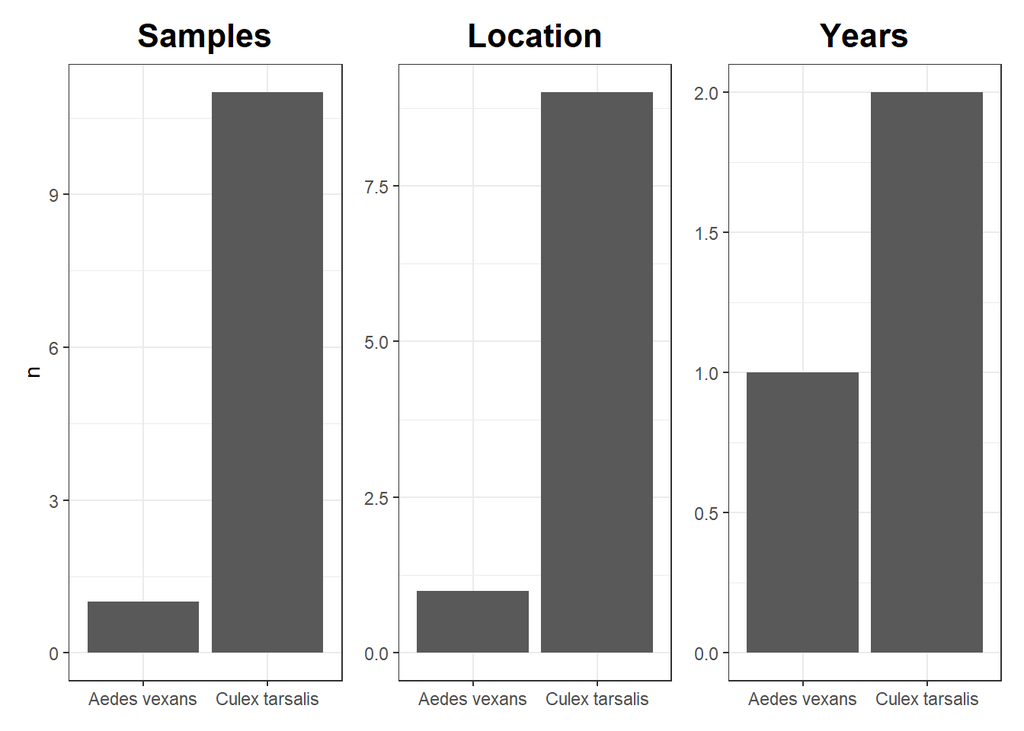

```r
virus_profile_plot("Wuhan mosquito virus 6")
```

```r
virus_profile_table("Wuhan mosquito virus 6")
```

Summary Stats for Wuhan mosquito virus 6

| Longest Contig | Shortest Contig | Average Nt Identity | Max Nt Identity | Min Nt Identity |
| --- | --- | --- | --- | --- |
| 2467 | 252 | 99.25 | 100.00 | 98.46 |

WMV6 is a virus in the family *Orthomyxoviridae* and is common in *Culex* mosquitoes around the world. It has six segments, all of which were recovered in our samples.

## Astopletus virus

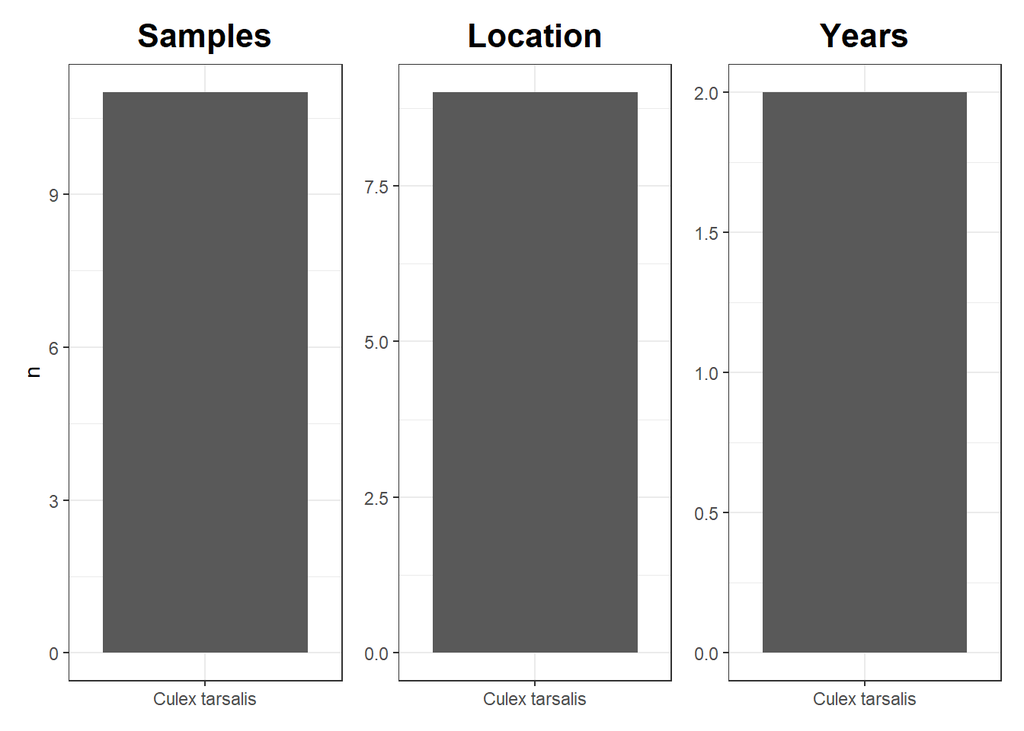

```r
virus_profile_plot("Astopletus virus")
```

```r
virus_profile_table("Astopletus virus")
```

Summary Stats for Astopletus virus

| Longest Contig | Shortest Contig | Average Nt Identity | Max Nt Identity | Min Nt Identity |
| --- | --- | --- | --- | --- |
| 1044 | 464 | 98.71 | 99.78 | 96.69 |

## Ballard Lake Virus

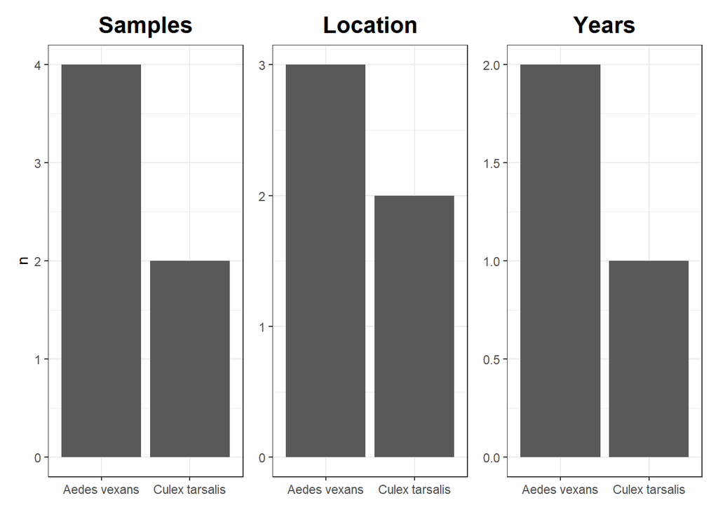

```r
virus_profile_plot("Ballard Lake virus")
```

```r
virus_profile_table("Ballard Lake virus")
```

Summary Stats for Ballard Lake virus

| Longest Contig | Shortest Contig | Average Nt Identity | Max Nt Identity | Min Nt Identity |
| --- | --- | --- | --- | --- |
| 3440 | 707 | 99.94 | 99.97 | 99.85 |

# Save Data

```r
virus_master_2023 %>%
  write.csv(here("virus_master_2023.csv"))
```